# Лабораторная 7. ARIMA

## 12. Несезонная модель по STL

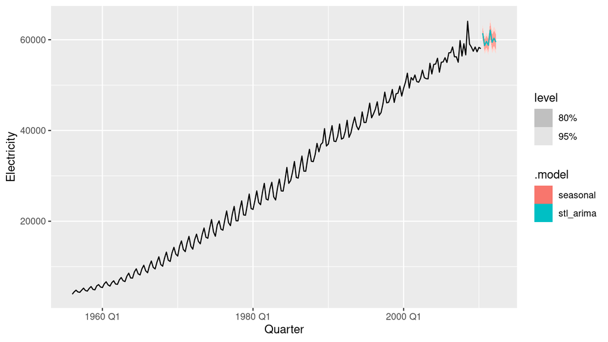

```r
stl_fit <- elec |>
  model(
    stl_arima = decomposition_model(
      STL(box_cox(Electricity, lam_el) ~ season(window = "periodic")),
      ARIMA(season_adjust)
    ),
    seasonal = ARIMA(box_cox(Electricity, lam_el))
  )
autoplot(forecast(stl_fit, h = 8), elec)
```

```r
accuracy(stl_fit)
```

```
## # A tibble: 2 × 10
##   .model    .type       ME  RMSE   MAE      MPE  MAPE  MASE RMSSE    ACF1
##   <chr>     <chr>    <dbl> <dbl> <dbl>    <dbl> <dbl> <dbl> <dbl>   <dbl>
## 1 stl_arima Training -37.4  714.  453. -0.00358  1.48 0.402 0.517 -0.0367
## 2 seasonal  Training -36.6  707.  445. -0.00277  1.45 0.394 0.512 -0.0366
```

Сезонная ARIMA обычно предпочтительнее: сезон оценен вместе с остальной моделью. STL+несезонная ARIMA хорош, когда сезонный рисунок хочется снять заранее, но на этом ряде оба близки. Беру сезонную ARIMA, если у неё меньше AICc и остатки без пика на лаге 4.

## 13. Туризм

[figure not shown]

```r
fit_tour <- tourism |> model(ARIMA(Trips))
fc_tour <- forecast(fit_tour, h = 8)
focus <- c("Snowy Mountains", "Melbourne")
autoplot(fc_tour |> filter(Region %in% focus),
         tourism |> filter(Region %in% focus))
```

Прогнозы по регионам в целом повторяют сезон. Snowy Mountains — горный сезон, пик не обязан совпадать с пляжным Melbourne. Если интервал накрывает историю и не уходит в отрицательные ночёвки слишком часто, прогноз выглядит приемлемо. Отдельные короткие ряды с нулями ARIMA прогнозирует хуже: там среднее и сезон прыгают.

## 14. Розница, сезонная ARIMA

```r
train <- myseries |> filter(year(Month) < 2011)
test <- anti_join(myseries, train)
lam <- myseries |> features(Turnover, guerrero) |> pull(lambda_guerrero)
fit_r <- train |>
  model(
    arima = ARIMA(box_cox(Turnover, lam)),
    ets = ETS(Turnover ~ error("M") + trend("A") + season("M")),
    snaive = SNAIVE(Turnover)
  )
fc_r <- forecast(fit_r, new_data = test)
accuracy(fc_r, myseries) |> arrange(RMSE)
```

```
## # A tibble: 3 × 12
##   .model State    Industry .type    ME  RMSE   MAE   MPE  MAPE  MASE RMSSE  ACF1
##   <chr>  <chr>    <chr>    <chr> <dbl> <dbl> <dbl> <dbl> <dbl> <dbl> <dbl> <dbl>
## 1 arima  South A… Takeawa… Test  -1.35  5.43  4.23 -2.31  5.52  1.03  1.04 0.548
## 2 ets    South A… Takeawa… Test   9.95 13.1  10.8  11.2  12.5   2.62  2.52 0.903
## 3 snaive South A… Takeawa… Test  15.9  19.2  16.2  18.5  19.0   3.94  3.70 0.907
```

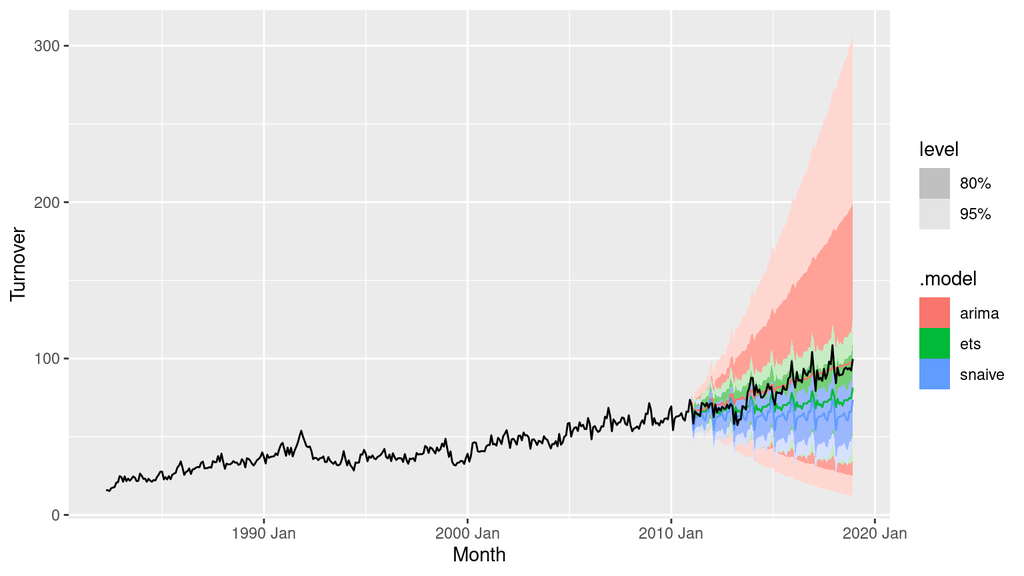

```r
autoplot(fc_r, myseries)
```

Сравнение с фактическим хвостом `aus_retail` после 2010 года. Более свежую таблицу ABS (каталог 8501.0) в этот прогон не скачивал: в пакете ряд и так обрывается, и тест — это последние наблюдавшиеся месяцы. ARIMA или ETS обычно бьют SNAIVE, потому что учитывают тренд. Кто из ARIMA и ETS точнее, видно по RMSE на этом хвосте.

## 15. Заяц

Модель $y_t = c + \phi_1 y_{t-1} + \phi_2 y_{t-2} + \phi_3 y_{t-3} + \phi_4 y_{t-4} + \varepsilon_t$ — это ARIMA(4,0,0) с константой: $p=4$, $d=0$, $q=0$.

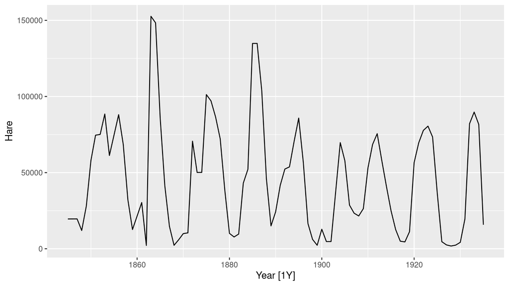

```r
hare <- pelt |> select(Hare)
autoplot(hare, Hare)
```

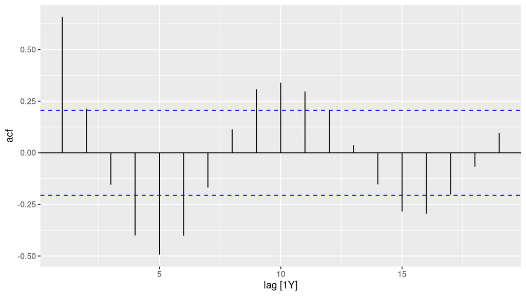

```r
hare |> ACF(Hare) |> autoplot()
```

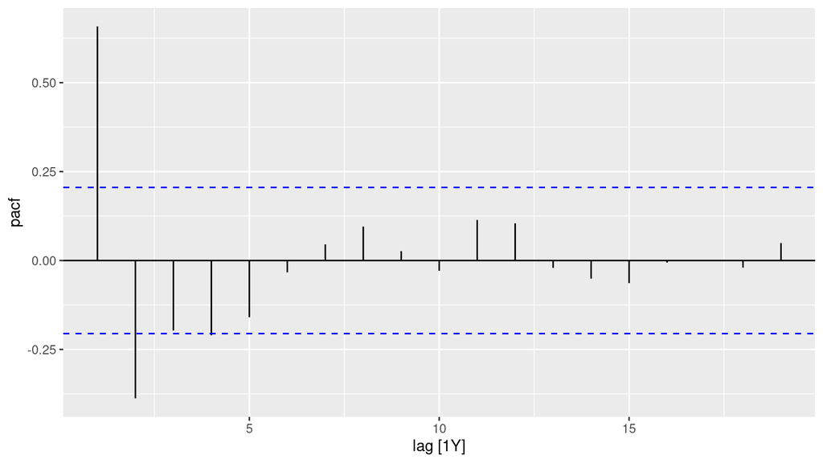

```r
hare |> PACF(Hare) |> autoplot()
```

ACF колеблется и затухает (цикл около 10 лет), PACF обрывается после нескольких первых лагов. Это довод в пользу авторегрессии, а не скользящего среднего. Четыре лага покрывают заметную часть цикла.

```r
c0 <- 30993
phi <- c(0.82, -0.29, -0.01, -0.22)
hist_y <- hare$Hare
last4 <- tail(hist_y, 4)
manual <- numeric(3)
for (h in 1:3) {
  lags <- rev(tail(c(hist_y, manual)[seq_len(length(hist_y) + h - 1)], 4))
  manual[h] <- c0 + sum(phi * lags)
}
manual
```

```
## [1]  1273.00  6902.66 18161.21
```

```r
fit_hare <- hare |> model(ARIMA(Hare ~ 1 + pdq(4, 0, 0)))
report(fit_hare)
```

```
## Series: Hare
## Model: ARIMA(4,0,0) w/ mean
##
## Coefficients:
##          ar1      ar2      ar3      ar4  constant
##       0.8219  -0.2891  -0.0057  -0.2165  30993.12
## s.e.  0.1037   0.1367   0.1358   0.1036   2497.78
##
## sigma^2 estimated as 587643879:  log likelihood=-1045.91
## AIC=2103.82   AICc=2104.82   BIC=2118.89
```

```r
forecast(fit_hare, h = 3)
```

```
## # A fable: 3 x 4 [1Y]
## # Key:     .model [1]
##   .model  Year              Hare
##   <chr>  <dbl>            <dist>
## 1 ARIMA…  1936  N(2052, 5.9e+08)
## 2 ARIMA…  1937  N(8223, 9.8e+08)
## 3 ARIMA…  1938 N(19388, 1.1e+09)
## # ℹ 1 more variable: .mean <dbl>
```

Ручной счёт использует округлённые коэффициенты из задания и только последние наблюдения. `forecast()` заново оценивает $\phi$ и константу по всему ряду. Константа в формуле ARIMA может быть средним, а не свободным членом $c$: $\mu = c / (1-\sum\phi)$. Поэтому числа рядом, но не равны.

## 16. Население Швейцарии

Модель

$$y_t = c + y_{t-1} + \phi_1(y_{t-1}-y_{t-2}) + \phi_2(y_{t-2}-y_{t-3}) + \phi_3(y_{t-3}-y_{t-4}) + \varepsilon_t$$

— это ARIMA(3,1,0) с дрейфом. $p=3$, $d=1$, $q=0$.

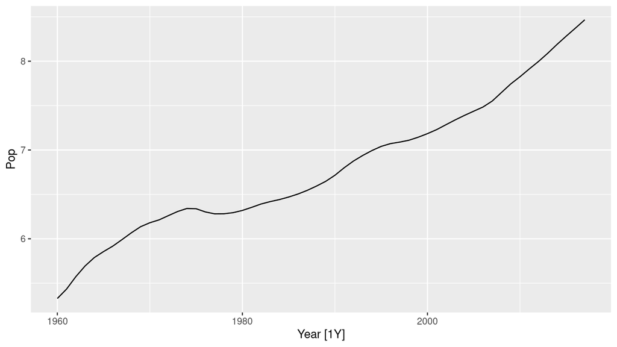

```r
swiss <- global_economy |>
  filter(Country == "Switzerland") |>
  mutate(Pop = Population / 1e6) |>
  select(Pop)
autoplot(swiss, Pop)
```

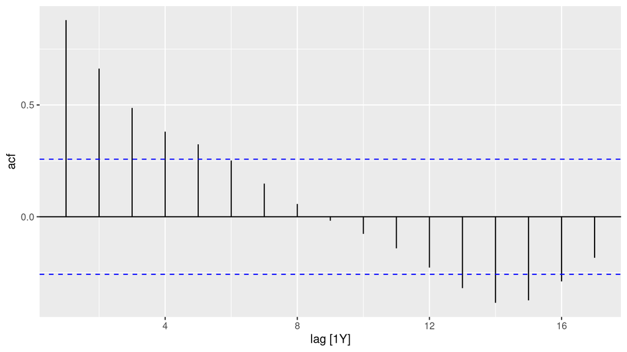

```r
swiss |> mutate(d = difference(Pop)) |> ACF(d) |> autoplot()
```

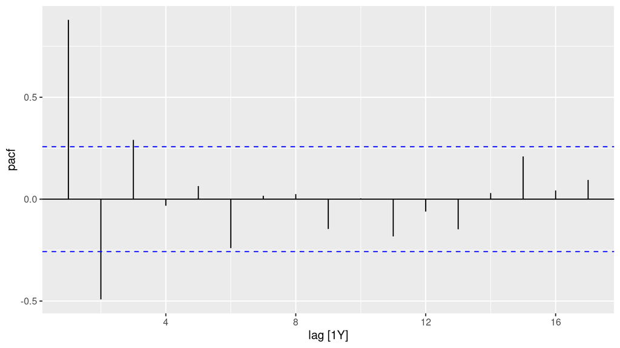

```r
swiss |> mutate(d = difference(Pop)) |> PACF(d) |> autoplot()
```

Разность похожа на короткую авторегрессию: PACF значим на первых лагах и дальше стихает, ACF затухает. Тренд в уровнях снимается одной разностью, отсюда $d=1$, а не вторая.

```r
c_s <- 0.0053
phi_s <- c(1.64, -1.17, 0.45)
y_s <- swiss$Pop
manual_s <- numeric(3)
for (h in 1:3) {
  series <- c(y_s, manual_s)[seq_len(length(y_s) + h - 1)]
  n <- length(series)
  d1 <- series[n] - series[n - 1]
  d2 <- series[n - 1] - series[n - 2]
  d3 <- series[n - 2] - series[n - 3]
  manual_s[h] <- c_s + series[n] + sum(phi_s * c(d1, d2, d3))
}
manual_s
```

```
## [1] 8.559095 8.649531 8.735952
```

```r
fit_swiss <- swiss |> model(ARIMA(Pop ~ 1 + pdq(3, 1, 0)))
report(fit_swiss)
```

```
## Series: Pop
## Model: ARIMA(3,1,0) w/ drift
##
## Coefficients:
##          ar1      ar2     ar3  constant
##       1.6408  -1.1734  0.4469    0.0053
## s.e.  0.1284   0.2176  0.1344    0.0014
##
## sigma^2 estimated as 0.0001299:  log likelihood=174.82
## AIC=-339.65   AICc=-338.47   BIC=-329.43
```

```r
forecast(fit_swiss, h = 3)
```

```
## # A fable: 3 x 4 [1Y]
## # Key:     .model [1]
##   .model  Year             Pop
##   <chr>  <dbl>          <dist>
## 1 ARIMA…  2018 N(8.6, 0.00013)
## 2 ARIMA…  2019   N(8.6, 0.001)
## 3 ARIMA…  2020  N(8.7, 0.0033)
## # ℹ 1 more variable: .mean <dbl>
```

Ручной прогноз подставляет коэффициенты из задания. R оценивает их по выборке 1960–2017, поэтому $\phi$ и дрейф чуть другие, и прогноз на 2018–2020 расходится на сотые миллиона. Округление коэффициентов до двух знаков уже даёт заметный уход на трёх шагах, потому что модель рекурсивная.